# Projet GLM-GAM

### Report results

Resulting from our analysis regarding the frequency (Poisson) and severity (Gamma) models, here is what we conclude. While most main effects, without interaction, have a significant effect on the frequency of claims, we cannot say the same for the severity model. Indeed, most if not all the coefficients are not considered significant. This can be easily explained by the idea that no feature corresponding to a policyholder or policy might indicate the severity of a claim, being mainly circumstantial.

Let’s first develop the final model regarding the frequency, namely *rec_8*. We achieve all coefficients in the model to be significant while obtaining optimal performance indicators. They are the following :

```r
df_freq[9,]
```

```
##   Model    AIC      BIC  Anova       CV Residual Deviance
## 9  rec8 100289 100445.6 0.2025 0.383995             69945
```

```r
summary(extract_fit_engine(m8_fit))
```

```
##
## Call:
## stats::glm(formula = NCLAIMS ~ offset(log(EXP)) + . - EXP, family = stats::poisson,
##     data = data)
##
## Coefficients:
##                      Estimate Std. Error z value Pr(>|z|)
## (Intercept)          -2.20643    0.03138 -70.311  < 2e-16 ***
## COVERAGEAll          -0.05780    0.01747  -3.309 0.000936 ***
## FUELgasoline         -0.17352    0.01743  -9.953  < 2e-16 ***
## SEXfemale             0.04263    0.01815   2.348 0.018857 *
## FLEETY               -0.15283    0.04870  -3.138 0.001700 **
## AGEPH_fac(56.5,69.3] -0.21384    0.02360  -9.061  < 2e-16 ***
## AGEPH_fac(17.9,30.8]  0.18384    0.02143   8.579  < 2e-16 ***
## AGEPH_fac(69.3,82.2] -0.23635    0.03460  -6.831 8.44e-12 ***
## AGEC_facAll           0.04191    0.01807   2.320 0.020343 *
## POWER_fac(40,48]      0.09078    0.02545   3.566 0.000362 ***
## POWER_fac(48,55]      0.09219    0.02447   3.767 0.000165 ***
## POWER_fac(55,66]      0.10133    0.02622   3.864 0.000112 ***
## POWER_fac(66,243]     0.20262    0.02547   7.955 1.79e-15 ***
## BM_fac(0,5]           0.22120    0.02016  10.974  < 2e-16 ***
## BM_fac(5,11]          0.59481    0.02277  26.127  < 2e-16 ***
## BM_fac(11,22]         0.81801    0.03904  20.951  < 2e-16 ***
## ---
## Signif. codes:  0 '***' 0.001 '**' 0.01 '*' 0.05 '.' 0.1 ' ' 1
##
## (Dispersion parameter for poisson family taken to be 1)
##
##     Null deviance: 71970  on 130584  degrees of freedom
## Residual deviance: 69945  on 130569  degrees of freedom
## AIC: 100289
##
## Number of Fisher Scoring iterations: 6
```

The Poisson GLM is estimated with the exposure as offset, so all coefficients are interpreted as multiplicative effects on the claim frequency, holding exposure constant and relative to their respective reference categories.

The intercept corresponds to the baseline log–claim frequency for a policyholder in all reference categories (*TPL* coverage, *diesel* fuel, *male*, *non-fleet* use, policyholder aged between 31 and 56 years old, car age between 0 and 5, *lowest power* class and *lowest bonus–malus* level). The exponential of the intercept gives the baseline (reference level) expected claim frequency per unit of exposure, being equal to a claim frequency of 11%. Hereunder, we define how the claim frequency evolves with respect to particular characteristics.

**Coverage** type has a statistically significant effect: policies with PO and FO (All) coverage exhibit a lower claim frequency than the reference coverage (TPL), with an estimated decrease of about 5.6%. It suggests a more cautious behavior or stronger underwriting selection. Vehicles running on **gasoline** have a substantially lower expected claim frequency (around 16% less) compared to *diesel* running vehicles, indicating a materially safer risk profile. **Female** policyholders display a slightly higher claim frequency (approximately +4.4%) compared to males, although the magnitude of the effect remains modest despite statistical significance. **Fleet** vehicles are associated with a significantly lower claim frequency (around −14%), which may reflect professional use, structured driving patterns or stronger risk management.

**Policyholder age (AGEPH)** shows a pronounced and non-linear relationship with claim frequency. Compared to the reference age group, younger drivers (17.9–30.8 years) have a significantly higher claim frequency (approximately +20%), while older drivers (56.5–69.3 and 69.3–82.2 years) exhibit substantially lower frequencies (around −19% to −21%). This pattern is consistent with well-documented life-cycle effects in motor insurance risk.

**Vehicle age (AGEC)** also contributes positively to claim frequency: cars older than 5 years have an estimated increase of about 4.3% relative to the reference group 0 to 5, indicating slightly higher risk for older or non-baseline vehicles. **Engine power** displays a clear monotonic effect: higher power classes are associated with progressively higher claim frequencies, ranging from roughly +9% for moderate power vehicles to more than +22% for the highest power class, reflecting increased driving intensity or risk-taking behavior.

Finally, the **bonus–malus (BM)** factor emerges as the strongest predictor in the model. Relative to the level 0, higher BM levels correspond to sharply increasing claim frequencies, with effects ranging from approximately +25% up to more than +125% for levels between 12 and 22. This confirms the strong persistence of individual risk and the high predictive power of past claims experience.

```r
df_sev[9,]
```

```
##   Model    AIC      BIC  Anova     MAE     RMSE Residual Deviance
## 9  sev7 239036 239149.7 0.9831 1826.47 13358.29             35697
```

```r
summary(extract_fit_engine(s7_fit))
```

```
##
## Call:
## stats::glm(formula = AVG ~ ., family = ~Gamma(link = "log"),
##     data = data)
##
## Coefficients:
##                    Estimate Std. Error t value Pr(>|t|)
## (Intercept)        7.008294   0.225592  31.066   <2e-16 ***
## COVERAGEPO        -0.147592   0.129806  -1.137   0.2555
## COVERAGEFO         0.238875   0.180704   1.322   0.1862
## FUELgasoline       0.168115   0.118873   1.414   0.1573
## SEXfemale          0.094775   0.123072   0.770   0.4413
## AGEPH_fac2        -0.045917   0.135550  -0.339   0.7348
## AGEPH_fac1        -0.256827   0.134006  -1.917   0.0553 .
## AGEC_fac(5,48]     0.191084   0.128087   1.492   0.1358
## POWER_fac(40,48]  -0.079601   0.173904  -0.458   0.6472
## POWER_fac(48,55]   0.071101   0.166871   0.426   0.6701
## POWER_fac(55,66]   0.352743   0.179371   1.967   0.0493 *
## POWER_fac(66,243]  0.014442   0.172112   0.084   0.9331
## BM_fac(0,5]        0.005242   0.135246   0.039   0.9691
## BM_fac(5,22]       0.328594   0.141420   2.324   0.0202 *
## ---
## Signif. codes:  0 '***' 0.001 '**' 0.01 '*' 0.05 '.' 0.1 ' ' 1
##
## (Dispersion parameter for Gamma family taken to be 42.04202)
##
##     Null deviance: 37162  on 14637  degrees of freedom
## Residual deviance: 35697  on 14624  degrees of freedom
## AIC: 239036
##
## Number of Fisher Scoring iterations: 14
```

Analyzing significant coefficient is a bit less straightforward in this case since most of them are not. The average claim amount for a policy corresponding to the reference level has an **average claim of 1105,44**. This prediction can be assumed to all the other non-significant factors as well. But for the two significant characteristics, we observe that vehicle with horsepower between 56 and 66 kilowatts tend to increase the severity by 42%. It is surprising that the same effect has not been observed for even higher horsepower though. Furthermore, for policyholders sitting between level 6 and 22 on the bonus-malus ladder increase the severity by 39%.

Below, we computed insurance premiums as a function of the policyholder’s age and its level on the bonus-malus scale. To properly calculate the premium, we have thus fixed all other characteristics to the reference level, knowingly a man driving a diesel car younger than 5 years old with horsepower lower than 40kw. The car is for private use and is not part of a fleet, while being covered under Third Party policy (TPL). Let’s recall that the insurance premium is computed with: $Premium_i = Frequency_i \times Severity_i$ with i being the specific condition to each policyholder. We only have one factor influencing severity, which is for policyholders in levels higher than 5 in the bonus-malus scale with a multiplicator level equal to $exp(0.328594)$. Then with respect to frequency, we add multiplicator coefficient depending on age and level on the bonus-malus ladder.

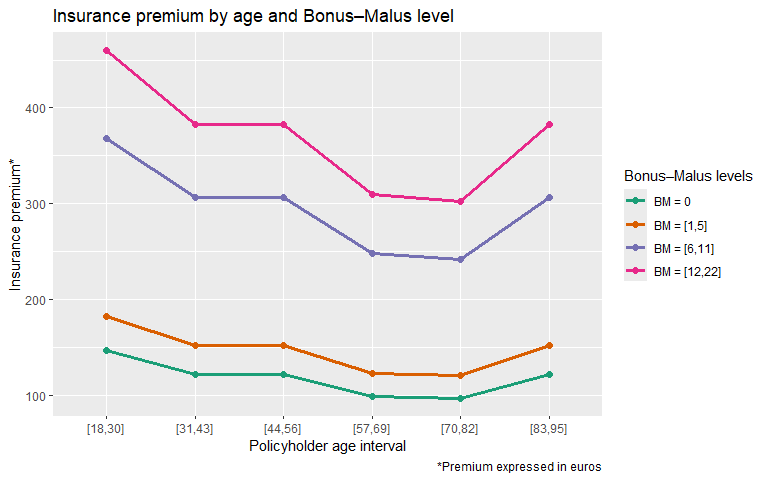

```r
# Reference level with BM=0 and AGEPH [31,43]
r0 <- exp(-2.20643)*exp(7.008294)

# BM = 0
pi_11 <- r0 * exp(0.18384)  #AGE [18,30]
pi_12 <- r0                 #AGE [31,43]
pi_13 <- r0                 #AGE [44,56]
pi_14 <- r0 * exp(-0.21384) #AGE [57,69]
pi_15 <- r0 * exp(-0.23635) #AGE [70,82]
pi_16 <- r0                 #AGE [83,95]
BM0<- c(pi_11, pi_12, pi_13, pi_14, pi_15, pi_16)

# BM = [1,5]
pi_21 <- r0 * exp(0.22120 + 0.18384)  #AGE [18,30]
pi_22 <- r0 * exp(0.22120)            #AGE [31,43]
pi_23 <- r0 * exp(0.22120)            #AGE [44,56]
pi_24 <- r0 * exp(0.22120 - 0.21384)  #AGE [57,69]
pi_25 <- r0 * exp(0.22120 - 0.23635)  #AGE [70,82]
pi_26 <- r0 * exp(0.22120)            #AGE [83,95]
BM1<- c(pi_21, pi_22, pi_23, pi_24, pi_25, pi_26)

# BM = [6,11]
pi_31 <- r0 * exp(0.59481 + 0.18384) * exp(0.328594)  #AGE [18,30]
pi_32 <- r0 * exp(0.59481) * exp(0.328594)            #AGE [31,43]
pi_33 <- r0 * exp(0.59481) * exp(0.328594)            #AGE [44,56]
pi_34 <- r0 * exp(0.59481 - 0.21384) * exp(0.328594)  #AGE [57,69]
pi_35 <- r0 * exp(0.59481 - 0.23635) * exp(0.328594)  #AGE [70,82]
pi_36 <- r0 * exp(0.59481)          * exp(0.328594)   #AGE [83,95]
BM6<- c(pi_31, pi_32, pi_33, pi_34, pi_35, pi_36)

# BM = [12,22]
pi_41 <- r0 * exp(0.81801 + 0.18384) * exp(0.328594)  #AGE [18,30]
pi_42 <- r0 * exp(0.81801) * exp(0.328594)            #AGE [31,43]
pi_43 <- r0 * exp(0.81801) * exp(0.328594)            #AGE [44,56]
pi_44 <- r0 * exp(0.81801 - 0.21384) * exp(0.328594)  #AGE [57,69]
pi_45 <- r0 * exp(0.81801 - 0.23635) * exp(0.328594)  #AGE [70,82]
pi_46 <- r0 * exp(0.81801) * exp(0.328594)            #AGE [83,95]
BM12<- c(pi_41, pi_42, pi_43, pi_44, pi_45, pi_46)

library(ggplot2)

age_levels <- c(
  "[18,30]", "[31,43]", "[44,56]",
  "[57,69]", "[70,82]", "[83,95]"
)

premium_df <- data.frame(
  AGEPH = factor(
    rep(age_levels, times = 4),
    levels = age_levels
  ),
  Premium = c(BM0, BM1, BM6, BM12),
  BM = factor(
    rep(c("BM = 0", "BM = [1,5]", "BM = [6,11]", "BM = [12,22]"),
        each = length(age_levels))
  )
)


ggplot(premium_df,
       aes(x = AGEPH, y = Premium, group = BM, color = factor(BM, levels = c(
    "BM = 0",
    "BM = [1,5]",
    "BM = [6,11]",
    "BM = [12,22]"
  )))) +
  geom_line(linewidth = 1.1) +
  geom_point(size = 2) +
  scale_color_brewer(palette = "Dark2") +
  labs(
    x = "Policyholder age interval",
    y = "Insurance premium*",
    color = "Bonus–Malus levels",
    title = "Insurance premium by age and Bonus–Malus level",
    caption = "*Premium expressed in euros"
  ) +
  theme_minimal(base_size = 13) +
  theme(
    plot.caption = element_text(
    size = 9,
    hjust = 0,     # left aligned
    margin = margin(t = 10)
    ),
    legend.position = "right",
    axis.text.x = element_text(angle = 0)
  )+
  theme_gray()
```

# GAM models

```r
require("mgcv")
require("plyr")
require("ggplot2")
require("gridExtra")
if (!require("parallel")) install.packages("parallel")
require("parallel")
require("arrow")
require("tidymodels")
```

Before getting started with GAMs, it is important to understand that it is a model based on GLMs, which is specifically made to deal with continuous variables. More specifically, we will use the continuous variables used in our GLM models and will add two more, long and lat, accounting for the longitude and latitude where the policyholder resides. To properly include continuous variables, GAMs use a smoothing function *s()*. As evoked, we will deal with longitude and latitude information from each policyholder and need to include this information into our GAM as well. To this end, we may use a bivariate function $f(long,lat)$ to account for the spatial metrics. There is two possible smoothing functions that might be used for bivariate functions, s or te, but we will use *s( ,by=“tp”)* as it is more suited for for quantities measured in same units, such as spatial effects.

## Frequency model with smoothing

Computational time is quite extensive while dealing with gam. Therefore, we will rely on the bam function to lower the time needed while using recipe to fasten the process. For the sake of comparison, we test the two different bivariate smoothing functions, namely *s()* and *te()* to assess which one retrieves the highest Log-likelihood result.

```r
set.seed(21)
in_training = createDataPartition(mtpl_be$NCLAIMS, times = 1, p = 0.8, list = FALSE)
training_set = mtpl_be[in_training, ]
testing_set = mtpl_be[-in_training, ]

require(parallel)
cl = makeCluster(detectCores() - 1)
rec <- recipe(NCLAIMS ~ POWER +  COVERAGE + FUEL+ FLEET + USE + SEX + AGEPH + AGEC+ BM + LONG + LAT + EXP, data = training_set)%>%
  prep()

m_bam = bam(NCLAIMS ~ offset(log(EXP)) +  COVERAGE + FUEL + FLEET + USE + SEX + s(POWER) + s(AGEC) + s(AGEPH) + s(BM) + te(LONG,LAT), data = bake(rec, training_set),
    family = poisson(link = log), cluster = cl)
stopCluster(cl)
logLik.gam(m_bam)
```

```
## 'log Lik.' -49861.82 (df=48.31019)
```

```r
cl = makeCluster(detectCores() - 1)
rec <- recipe(NCLAIMS ~ POWER +  COVERAGE + FUEL+ FLEET + USE + SEX + AGEPH + AGEC+ BM + LONG + LAT + EXP, data = training_set)%>%
  prep()

m0_bam = bam(NCLAIMS ~ offset(log(EXP)) +  COVERAGE + FUEL + FLEET + USE + SEX + s(POWER) + s(AGEC) + s(AGEPH) + s(BM) + s(LONG,LAT, bs="tp"), data = bake(rec, training_set),
    family = poisson(link = log), cluster = cl)
stopCluster(cl)

logLik.gam(m0_bam)
```

```
## 'log Lik.' -49835.92 (df=54.16803)
```

The log-likelihood is thus maximized with the smoothing function *s( ,bs=“tp”)* and will therefore use it for our following computations

```r
AIC(m0_bam); BIC(m0_bam)
```

```
## [1] 99780.17
```

```
## [1] 100309.9
```

```r
summary(m0_bam)
```

```
##
## Family: poisson
## Link function: log
##
## Formula:
## NCLAIMS ~ offset(log(EXP)) + COVERAGE + FUEL + FLEET + USE +
##     SEX + s(POWER) + s(AGEC) + s(AGEPH) + s(BM) + s(LONG, LAT,
##     bs = "tp")
##
## Parametric coefficients:
##              Estimate Std. Error  z value Pr(>|z|)
## (Intercept)  -1.84703    0.01656 -111.530  < 2e-16 ***
## COVERAGEPO   -0.10269    0.02004   -5.124 2.98e-07 ***
## COVERAGEFO   -0.10018    0.02813   -3.561  0.00037 ***
## FUELgasoline -0.20082    0.01750  -11.476  < 2e-16 ***
## FLEETY       -0.14862    0.04897   -3.035  0.00241 **
## USEwork      -0.06392    0.03755   -1.702  0.08874 .
## SEXfemale     0.03494    0.01823    1.916  0.05531 .
## ---
## Signif. codes:  0 '***' 0.001 '**' 0.01 '*' 0.05 '.' 0.1 ' ' 1
##
## Approximate significance of smooth terms:
##                edf Ref.df Chi.sq p-value
## s(POWER)     2.718  3.459  67.50  <2e-16 ***
## s(AGEC)      5.339  6.146  38.15  <2e-16 ***
## s(AGEPH)     6.156  7.168 247.44  <2e-16 ***
## s(BM)        5.417  6.434 782.89  <2e-16 ***
## s(LONG,LAT) 23.243 26.933 308.87  <2e-16 ***
## ---
## Signif. codes:  0 '***' 0.001 '**' 0.01 '*' 0.05 '.' 0.1 ' ' 1
##
## R-sq.(adj) =  0.0198   Deviance explained = 3.73%
## fREML = 1.9597e+05  Scale est. = 1         n = 130585
```

At first glance, we can already observe in the summary that continuous variables are being processed differently and that they are all significant. Regarding discrete variables, they all appear highly significant, except for *USE* and *SEX*. As in the previous section regarding GLMs, we use specific performance indicator to assess the accuracy and fit of our models. Naturally, we rely again on the AIC and BIC, but we will reintroduce as well the cross-validation test to properly assess the predictive performance of our GAMs. Here we computed the k-folds cross-validation and will compare the mean of the folds with the ones from other models. Furthermore, we include the maximization of the log-likelihood as performance indicator as well as the adjusted R-squared which evaluates the percentage of the model being explained. Therefore, we aim for higher log-likelihood value and R-squared.

```r
require(caret)
set.seed(81)
folds = createFolds(training_set$NCLAIMS, k = 5)
res0 = lapply(folds, function(X) {
    cl = makeCluster(detectCores() - 1)  # Number of cores to use
    m0_bam = bam(NCLAIMS ~ offset(log(EXP)) +  COVERAGE + FUEL + FLEET + USE + SEX + s(POWER) + s(AGEC) + s(AGEPH) + s(BM) + s(LONG,LAT, bs="tp"),
        data = bake(rec, training_set[-X, ]), family = poisson(link = log), cluster = cl)
    stopCluster(cl)
    pred = predict(m0_bam, bake(rec, training_set[X, ]), type = "response")
    sum(dpois(x = bake(rec, training_set[X, ])$NCLAIMS, lambda = pred, log = TRUE))
})
res0
```

```
## $Fold1
## [1] -9960.493
##
## $Fold2
## [1] -9843.953
##
## $Fold3
## [1] -10069.22
##
## $Fold4
## [1] -10089.37
##
## $Fold5
## [1] -9932.975
```

```r
apply(cbind(unlist(res0)), 2, mean)
```

```
## [1] -9979.203
```

Let’s now get rid of the USE and SEX to assess how it impacts our model.

```r
cl = makeCluster(detectCores() - 1)
rec1 <- recipe(NCLAIMS ~ POWER +  COVERAGE + FUEL+ FLEET + AGEPH + AGEC+ BM + LONG + LAT + EXP, data = training_set)%>%
  prep()

m1_bam = bam(NCLAIMS ~ offset(log(EXP)) +  COVERAGE + FUEL + FLEET  + s(POWER) + s(AGEC) + s(AGEPH) + s(BM) + s(LONG,LAT, bs="tp"), data = bake(rec1, training_set),
    family = poisson(link = log), cluster = cl)
stopCluster(cl)
AIC(m1_bam); BIC(m1_bam)
```

```
## [1] 99784.1
```

```
## [1] 100300
```

```r
logLik.gam(m1_bam)
```

```
## 'log Lik.' -49839.3 (df=52.75181)
```

```r
summary(m1_bam)
```

```
##
## Family: poisson
## Link function: log
##
## Formula:
## NCLAIMS ~ offset(log(EXP)) + COVERAGE + FUEL + FLEET + s(POWER) +
##     s(AGEC) + s(AGEPH) + s(BM) + s(LONG, LAT, bs = "tp")
##
## Parametric coefficients:
##              Estimate Std. Error  z value Pr(>|z|)
## (Intercept)  -1.84487    0.01613 -114.407  < 2e-16 ***
## COVERAGEPO   -0.10265    0.02003   -5.124 2.99e-07 ***
## COVERAGEFO   -0.10255    0.02804   -3.657 0.000255 ***
## FUELgasoline -0.19460    0.01728  -11.263  < 2e-16 ***
## FLEETY       -0.15224    0.04884   -3.117 0.001825 **
## ---
## Signif. codes:  0 '***' 0.001 '**' 0.01 '*' 0.05 '.' 0.1 ' ' 1
##
## Approximate significance of smooth terms:
##                edf Ref.df Chi.sq p-value
## s(POWER)     2.590  3.303  61.68 < 2e-16 ***
## s(AGEC)      5.354  6.159  38.72 3.2e-06 ***
## s(AGEPH)     6.156  7.168 257.53 < 2e-16 ***
## s(BM)        5.444  6.461 789.48 < 2e-16 ***
## s(LONG,LAT) 23.250 26.937 310.29 < 2e-16 ***
## ---
## Signif. codes:  0 '***' 0.001 '**' 0.01 '*' 0.05 '.' 0.1 ' ' 1
##
## R-sq.(adj) =  0.0198   Deviance explained = 3.72%
## fREML = 1.9599e+05  Scale est. = 1         n = 130585
```

```r
anova(m0_bam, m1_bam, test = "Chisq")
```

```
## Analysis of Deviance Table
##
## Model 1: NCLAIMS ~ offset(log(EXP)) + COVERAGE + FUEL + FLEET + USE +
##     SEX + s(POWER) + s(AGEC) + s(AGEPH) + s(BM) + s(LONG, LAT,
##     bs = "tp")
## Model 2: NCLAIMS ~ offset(log(EXP)) + COVERAGE + FUEL + FLEET + s(POWER) +
##     s(AGEC) + s(AGEPH) + s(BM) + s(LONG, LAT, bs = "tp")
##   Resid. Df Resid. Dev     Df Deviance Pr(>Chi)
## 1    130524      69360
## 2    130525      69367 -1.448  -6.7614  0.01807 *
## ---
## Signif. codes:  0 '***' 0.001 '**' 0.01 '*' 0.05 '.' 0.1 ' ' 1
```

When implementing a second model without the *USE* and *SEX* variable, we see that even though we obtain a better BIC, the AIC, Log-likelihood perform poorer. Moreover, the anova test tells us that at least one of the two coefficients removed has a value different than 0. We now implement the same model but we add *SEX* back as it is the coefficient with the lowest p-value of the two in *m0_bam*.

```r
cl = makeCluster(detectCores() - 1)
rec2 <- recipe(NCLAIMS ~ POWER +  COVERAGE + FUEL+ FLEET + SEX + AGEPH + AGEC+ BM + LONG + LAT + EXP, data = training_set)%>%
  prep()

m2_bam = bam(NCLAIMS ~ offset(log(EXP)) +  COVERAGE + FUEL + FLEET + s(POWER) + SEX + s(AGEPH) + s(BM) + s(AGEC) + s(LONG,LAT, bs="tp"), data = bake(rec2, training_set),
    family = poisson(link = log), cluster = cl)
stopCluster(cl)
AIC(m2_bam); BIC(m2_bam)
```

```
## [1] 99780.55
```

```
## [1] 100302.9
```

```r
logLik.gam(m2_bam)
```

```
## 'log Lik.' -49836.87 (df=53.40711)
```

```r
summary(m2_bam)
```

```
##
## Family: poisson
## Link function: log
##
## Formula:
## NCLAIMS ~ offset(log(EXP)) + COVERAGE + FUEL + FLEET + s(POWER) +
##     SEX + s(AGEPH) + s(BM) + s(AGEC) + s(LONG, LAT, bs = "tp")
##
## Parametric coefficients:
##              Estimate Std. Error  z value Pr(>|z|)
## (Intercept)  -1.85140    0.01645 -112.570  < 2e-16 ***
## COVERAGEPO   -0.10329    0.02004   -5.156 2.53e-07 ***
## COVERAGEFO   -0.10380    0.02805   -3.700 0.000216 ***
## FUELgasoline -0.19792    0.01749  -11.317  < 2e-16 ***
## FLEETY       -0.15464    0.04885   -3.166 0.001548 **
## SEXfemale     0.03523    0.01823    1.932 0.053311 .
## ---
## Signif. codes:  0 '***' 0.001 '**' 0.01 '*' 0.05 '.' 0.1 ' ' 1
##
## Approximate significance of smooth terms:
##                edf Ref.df Chi.sq  p-value
## s(POWER)     2.949  3.733  65.65  < 2e-16 ***
## s(AGEPH)     6.158  7.169 251.25  < 2e-16 ***
## s(BM)        5.423  6.440 780.53  < 2e-16 ***
## s(AGEC)      5.366  6.170  38.52 3.24e-06 ***
## s(LONG,LAT) 23.250 26.937 309.72  < 2e-16 ***
## ---
## Signif. codes:  0 '***' 0.001 '**' 0.01 '*' 0.05 '.' 0.1 ' ' 1
##
## R-sq.(adj) =  0.0198   Deviance explained = 3.73%
## fREML = 1.9595e+05  Scale est. = 1         n = 130585
```

```r
anova(m0_bam, m2_bam, test = "Chisq")
```

```
## Analysis of Deviance Table
##
## Model 1: NCLAIMS ~ offset(log(EXP)) + COVERAGE + FUEL + FLEET + USE +
##     SEX + s(POWER) + s(AGEC) + s(AGEPH) + s(BM) + s(LONG, LAT,
##     bs = "tp")
## Model 2: NCLAIMS ~ offset(log(EXP)) + COVERAGE + FUEL + FLEET + s(POWER) +
##     SEX + s(AGEPH) + s(BM) + s(AGEC) + s(LONG, LAT, bs = "tp")
##   Resid. Df Resid. Dev       Df Deviance Pr(>Chi)
## 1    130524      69360
## 2    130524      69362 -0.72147  -1.8954   0.1135
```

Unfortunately, putting back SEX has not made that variable significant. The anova test shows that we can keep this simpler model over m0_bam and BIC supports that stance. On the other hand, Log-likelihood is not maximized and AIC is not improved.

```r
set.seed(82)
folds = createFolds(training_set$NCLAIMS, k = 5)
res2 = lapply(folds, function(X) {
    cl = makeCluster(detectCores() - 1)  # Number of cores to use
    m2_bam = bam(NCLAIMS ~ offset(log(EXP)) +  COVERAGE + FUEL + FLEET + s(POWER) + s(AGEC) + s(AGEPH) + s(BM) + s(LONG,LAT, bs="tp"),
        data = bake(rec2, training_set[-X, ]), family = poisson(link = log), cluster = cl)
    stopCluster(cl)
    pred = predict(m2_bam, bake(rec, training_set[X, ]), type = "response")
    sum(dpois(x = bake(rec2, training_set[X, ])$NCLAIMS, lambda = pred, log = TRUE))
})

res2
```

```
## $Fold1
## [1] -9914.874
##
## $Fold2
## [1] -10009.83
##
## $Fold3
## [1] -10035.88
##
## $Fold4
## [1] -9872.378
##
## $Fold5
## [1] -10058.52
```

```r
apply(cbind(unlist(res0), unlist(res2)), 2, mean)
```

```
## [1] -9979.203 -9978.296
```

Cross validation results display better performance for model *m2_bam*. Starting from here, we may explore a possible interaction between SEX and POWER or AGE to analyze if it makes our model more robust.

```r
cl = makeCluster(detectCores() - 1)
rec3 <- recipe(NCLAIMS ~ POWER +  COVERAGE + FUEL+ SEX+ FLEET + AGEPH + AGEC+ BM +
                 LONG + LAT + EXP, data = training_set)%>%
  prep()

m3_bam = bam(NCLAIMS ~ offset(log(EXP)) +  COVERAGE + FUEL + FLEET + s(POWER) + s(AGEC) + s(AGEPH, by=SEX) + s(BM) + s(LONG,LAT, bs="tp"), data = bake(rec3, training_set),
    family = poisson(link = log), cluster = cl)
stopCluster(cl)
AIC(m3_bam); BIC(m3_bam)
```

```
## [1] 99750.72
```

```
## [1] 100329.6
```

```r
logLik.gam(m3_bam)
```

```
## 'log Lik.' -49816.17 (df=59.18993)
```

```r
summary(m3_bam)
```

```
##
## Family: poisson
## Link function: log
##
## Formula:
## NCLAIMS ~ offset(log(EXP)) + COVERAGE + FUEL + FLEET + s(POWER) +
##     s(AGEC) + s(AGEPH, by = SEX) + s(BM) + s(LONG, LAT, bs = "tp")
##
## Parametric coefficients:
##              Estimate Std. Error  z value Pr(>|z|)
## (Intercept)  -1.84231    0.01605 -114.784  < 2e-16 ***
## COVERAGEPO   -0.10212    0.02003   -5.098 3.43e-07 ***
## COVERAGEFO   -0.10188    0.02803   -3.634 0.000279 ***
## FUELgasoline -0.19497    0.01714  -11.374  < 2e-16 ***
## FLEETY       -0.15092    0.04884   -3.090 0.002003 **
## ---
## Signif. codes:  0 '***' 0.001 '**' 0.01 '*' 0.05 '.' 0.1 ' ' 1
##
## Approximate significance of smooth terms:
##                       edf Ref.df Chi.sq  p-value
## s(POWER)            1.469  1.823  55.66  < 2e-16 ***
## s(AGEC)             5.339  6.145  39.37 2.92e-06 ***
## s(AGEPH):SEXmale    6.195  7.209 286.06  < 2e-16 ***
## s(AGEPH):SEXfemale  4.659  5.661  37.40 3.61e-06 ***
## s(BM)               5.417  6.433 777.12  < 2e-16 ***
## s(LONG,LAT)        23.220 26.918 310.94  < 2e-16 ***
## ---
## Signif. codes:  0 '***' 0.001 '**' 0.01 '*' 0.05 '.' 0.1 ' ' 1
##
## R-sq.(adj) =  0.0202   Deviance explained = 3.78%
## fREML = 1.9602e+05  Scale est. = 1         n = 130585
```

```r
anova(m0_bam, m3_bam, test = "Chisq")
```

```
## Analysis of Deviance Table
##
## Model 1: NCLAIMS ~ offset(log(EXP)) + COVERAGE + FUEL + FLEET + USE +
##     SEX + s(POWER) + s(AGEC) + s(AGEPH) + s(BM) + s(LONG, LAT,
##     bs = "tp")
## Model 2: NCLAIMS ~ offset(log(EXP)) + COVERAGE + FUEL + FLEET + s(POWER) +
##     s(AGEC) + s(AGEPH, by = SEX) + s(BM) + s(LONG, LAT, bs = "tp")
##   Resid. Df Resid. Dev    Df Deviance  Pr(>Chi)
## 1    130524      69360
## 2    130518      69320 5.647     39.5 3.908e-07 ***
## ---
## Signif. codes:  0 '***' 0.001 '**' 0.01 '*' 0.05 '.' 0.1 ' ' 1
```

```r
set.seed(82)
folds = createFolds(training_set$NCLAIMS, k = 5)
res3 = lapply(folds, function(X) {
    cl = makeCluster(detectCores() - 1)  # Number of cores to use
    m3_bam = bam(NCLAIMS ~ offset(log(EXP)) +  COVERAGE + FUEL + FLEET + s(POWER) +
                   s(AGEC) + s(AGEPH, by=SEX) + s(BM) + s(LONG,LAT, bs="tp"),
        data = bake(rec3, training_set[-X, ]), family = poisson(link = log), cluster = cl)
    stopCluster(cl)
    pred = predict(m3_bam, bake(rec, training_set[X, ]), type = "response")
    sum(dpois(x = bake(rec3, training_set[X, ])$NCLAIMS, lambda = pred, log = TRUE))
})

res3
```

```
## $Fold1
## [1] -9911.179
##
## $Fold2
## [1] -10011.39
##
## $Fold3
## [1] -10035.68
##
## $Fold4
## [1] -9866.599
##
## $Fold5
## [1] -10050.05
```

```r
apply(cbind(unlist(res0), unlist(res3)), 2, mean)
```

```
## [1] -9979.203 -9974.980
```

Now we compare with the interaction between SEX and POWER

```r
cl = makeCluster(detectCores() - 1)
rec4 <- recipe(NCLAIMS ~ POWER +  COVERAGE + FUEL+ SEX+ FLEET + AGEPH + AGEC+ BM +
                 LONG + LAT + EXP, data = training_set)%>%
  prep()

m4_bam = bam(NCLAIMS ~ offset(log(EXP)) +  COVERAGE + FUEL + FLEET + s(POWER, by=SEX) + s(AGEC) + s(AGEPH) + s(BM) + s(LONG,LAT, bs="tp"),
             data = bake(rec4, training_set),
    family = poisson(link = log), cluster = cl)
stopCluster(cl)
AIC(m4_bam); BIC(m4_bam)
```

```
## [1] 99767.38
```

```
## [1] 100267.5
```

```r
logLik.gam(m4_bam)
```

```
## 'log Lik.' -49832.55 (df=51.13644)
```

```r
summary(m4_bam)
```

```
##
## Family: poisson
## Link function: log
##
## Formula:
## NCLAIMS ~ offset(log(EXP)) + COVERAGE + FUEL + FLEET + s(POWER,
##     by = SEX) + s(AGEC) + s(AGEPH) + s(BM) + s(LONG, LAT, bs = "tp")
##
## Parametric coefficients:
##              Estimate Std. Error  z value Pr(>|z|)
## (Intercept)  -1.84291    0.01603 -114.949  < 2e-16 ***
## COVERAGEPO   -0.10197    0.02003   -5.090 3.57e-07 ***
## COVERAGEFO   -0.10158    0.02804   -3.622 0.000292 ***
## FUELgasoline -0.19030    0.01720  -11.067  < 2e-16 ***
## FLEETY       -0.15191    0.04884   -3.111 0.001867 **
## ---
## Signif. codes:  0 '***' 0.001 '**' 0.01 '*' 0.05 '.' 0.1 ' ' 1
##
## Approximate significance of smooth terms:
##                       edf Ref.df Chi.sq  p-value
## s(POWER):SEXmale    1.003  1.005  24.16 9.85e-07 ***
## s(POWER):SEXfemale  2.503  3.181  52.75  < 2e-16 ***
## s(AGEC)             5.339  6.145  39.03  < 2e-16 ***
## s(AGEPH)            6.156  7.168 262.10  < 2e-16 ***
## s(BM)               5.444  6.460 791.97  < 2e-16 ***
## s(LONG,LAT)        23.240 26.931 310.78  < 2e-16 ***
## ---
## Signif. codes:  0 '***' 0.001 '**' 0.01 '*' 0.05 '.' 0.1 ' ' 1
##
## R-sq.(adj) =   0.02   Deviance explained = 3.74%
## fREML = 1.9598e+05  Scale est. = 1         n = 130585
```

```r
anova(m0_bam, m4_bam, test = "Chisq")
```

```
## Analysis of Deviance Table
##
## Model 1: NCLAIMS ~ offset(log(EXP)) + COVERAGE + FUEL + FLEET + USE +
##     SEX + s(POWER) + s(AGEC) + s(AGEPH) + s(BM) + s(LONG, LAT,
##     bs = "tp")
## Model 2: NCLAIMS ~ offset(log(EXP)) + COVERAGE + FUEL + FLEET + s(POWER,
##     by = SEX) + s(AGEC) + s(AGEPH) + s(BM) + s(LONG, LAT, bs = "tp")
##   Resid. Df Resid. Dev      Df Deviance Pr(>Chi)
## 1    130524      69360
## 2    130527      69353 -3.0908   6.7354
```

```r
set.seed(82)
folds = createFolds(training_set$NCLAIMS, k = 5)
res4 = lapply(folds, function(X) {
    cl = makeCluster(detectCores() - 1)  # Number of cores to use
    m4_bam = bam(NCLAIMS ~ offset(log(EXP)) +  COVERAGE + FUEL + FLEET + s(POWER, by=SEX)
                 + s(AGEC) + s(AGEPH) + s(BM) + s(LONG,LAT, bs="tp"),
        data = bake(rec4, training_set[-X, ]), family = poisson(link = log), cluster = cl)
    stopCluster(cl)
    pred = predict(m4_bam, bake(rec, training_set[X, ]), type = "response")
    sum(dpois(x = bake(rec4, training_set[X, ])$NCLAIMS, lambda = pred, log = TRUE))
})

res4
```

```
## $Fold1
## [1] -9915.723
##
## $Fold2
## [1] -10008.46
##
## $Fold3
## [1] -10032.98
##
## $Fold4
## [1] -9872.978
##
## $Fold5
## [1] -10056.47
```

```r
apply(cbind(unlist(res0), unlist(res4)), 2, mean)
```

```
## [1] -9979.203 -9977.323
```

We find ourselves in an uneasy situation since the interaction between SEX and Age performs better in all aspects, except for a much poorer performance in terms of BIC. But we conclude that although the BIC is higher, the AIC suggests that *m3_bam* has additional parameters that genuinely improve fit beyond just adding complexity.

let’s now merge the coefficients from Coverage taking approximately the same value to simplify our model.

```r
cl = makeCluster(detectCores() - 1)
rec5 <- recipe(NCLAIMS ~ POWER +  COVERAGE + FUEL+ SEX + FLEET + AGEPH + AGEC+ BM + LONG
               + LAT + EXP, data = training_set)%>%
  step_mutate(COVERAGE = forcats::fct_collapse(COVERAGE, "(PO,FO)" = c("PO","FO")))%>%
  prep()

m5_bam = bam(NCLAIMS ~ offset(log(EXP)) +  COVERAGE + FUEL + FLEET + s(POWER) +
               s(AGEC) + s(AGEPH, by=SEX) + s(BM) + s(LONG,LAT, bs="tp"),
             data = bake(rec5, training_set), family = poisson(link = log), cluster = cl)
stopCluster(cl)
AIC(m5_bam); BIC(m5_bam)
```

```
## [1] 99748.73
```

```
## [1] 100318
```

```r
logLik.gam(m5_bam)
```

```
## 'log Lik.' -49816.16 (df=58.20502)
```

```r
summary(m5_bam)
```

```
##
## Family: poisson
## Link function: log
##
## Formula:
## NCLAIMS ~ offset(log(EXP)) + COVERAGE + FUEL + FLEET + s(POWER) +
##     s(AGEC) + s(AGEPH, by = SEX) + s(BM) + s(LONG, LAT, bs = "tp")
##
## Parametric coefficients:
##                 Estimate Std. Error  z value Pr(>|z|)
## (Intercept)     -1.84233    0.01601 -115.093  < 2e-16 ***
## COVERAGE(PO,FO) -0.10206    0.01859   -5.489 4.04e-08 ***
## FUELgasoline    -0.19495    0.01713  -11.380  < 2e-16 ***
## FLEETY          -0.15090    0.04880   -3.092  0.00199 **
## ---
## Signif. codes:  0 '***' 0.001 '**' 0.01 '*' 0.05 '.' 0.1 ' ' 1
##
## Approximate significance of smooth terms:
##                       edf Ref.df Chi.sq  p-value
## s(POWER)            1.480  1.840  55.88  < 2e-16 ***
## s(AGEC)             5.340  6.144  39.54 2.88e-06 ***
## s(AGEPH):SEXmale    6.195  7.209 286.07  < 2e-16 ***
## s(AGEPH):SEXfemale  4.658  5.660  37.39 3.61e-06 ***
## s(BM)               5.417  6.433 777.24  < 2e-16 ***
## s(LONG,LAT)        23.220 26.918 310.99  < 2e-16 ***
## ---
## Signif. codes:  0 '***' 0.001 '**' 0.01 '*' 0.05 '.' 0.1 ' ' 1
##
## R-sq.(adj) =  0.0202   Deviance explained = 3.78%
## fREML = 1.9602e+05  Scale est. = 1         n = 130585
```

```r
anova(m0_bam, m5_bam, test = "Chisq")
```

```
## Analysis of Deviance Table
##
## Model 1: NCLAIMS ~ offset(log(EXP)) + COVERAGE + FUEL + FLEET + USE +
##     SEX + s(POWER) + s(AGEC) + s(AGEPH) + s(BM) + s(LONG, LAT,
##     bs = "tp")
## Model 2: NCLAIMS ~ offset(log(EXP)) + COVERAGE + FUEL + FLEET + s(POWER) +
##     s(AGEC) + s(AGEPH, by = SEX) + s(BM) + s(LONG, LAT, bs = "tp")
##   Resid. Df Resid. Dev     Df Deviance  Pr(>Chi)
## 1    130524      69360
## 2    130519      69320 4.6661   39.515 1.259e-07 ***
## ---
## Signif. codes:  0 '***' 0.001 '**' 0.01 '*' 0.05 '.' 0.1 ' ' 1
```

```r
set.seed(82)
folds = createFolds(training_set$NCLAIMS, k = 5)
res5 = lapply(folds, function(X) {
    cl = makeCluster(detectCores() - 1)  # Number of cores to use
    m5_bam = bam(NCLAIMS ~ offset(log(EXP)) +  COVERAGE + FUEL + FLEET + s(POWER) + s(AGEC) + s(AGEPH, by=SEX) + s(BM) + s(LONG,LAT, bs="tp"),
        data = bake(rec5, training_set[-X, ]), family = poisson(link = log), cluster = cl)
    stopCluster(cl)
    pred = predict(m5_bam, bake(rec5, training_set[X, ]), type = "response")
    sum(dpois(x = bake(rec5, training_set[X, ])$NCLAIMS, lambda = pred, log = TRUE))
})

res5
```

```
## $Fold1
## [1] -9910.904
##
## $Fold2
## [1] -10011.3
##
## $Fold3
## [1] -10033.98
##
## $Fold4
## [1] -9866.581
##
## $Fold5
## [1] -10049.17
```

```r
apply(cbind(unlist(res0), unlist(res5)), 2, mean)
```

```
## [1] -9979.203 -9974.389
```

### Optimizing the number of nodes

Up to this point, the smoothed components of the continuous variables have been estimated using the default number of basis functions selected by the model. Having identified the optimal model specification, we now refine the model by assessing whether the chosen number of basis functions is sufficient. This is done using the **k.check** function, which provides diagnostic information on the adequacy of the smoothing parameters in the fitted Generalized Additive Model (GAM).

The *k.check* output includes the k-index, which evaluates whether the chosen basis dimension is large enough. Values of the k-index substantially below 1 indicate that the basis dimension may be too small, suggesting potential underfitting and loss of relevant information. In addition, we examine the estimated degrees of freedom (edf) for each smooth term, which reflect the complexity of the fitted relationship. An edf close to 1 indicates an approximately linear effect, whereas an edf approaching the maximum allowable value (k′) suggests that the smooth term may be constrained by an insufficient basis dimension.

Finally, the associated p-value tests the null hypothesis that the selected basis dimension is adequate. Based on these diagnostics, our strategy is to increase the basis dimension whenever the edf is too close to k′, thereby allowing the model to allocate additional degrees of freedom to the smooth term. This adjustment enhances the flexibility of the smoothed functions and reduces the risk of underfitting.

```r
k.check(m5_bam)
gam.check(m5_bam)
```

[output not shown]

With the results from *gam.check* and *k.check*, we assume that most smoothed parameters have large enough nodes, except for the spatial effect that might benefit from a higher k. We thus test with a k value of 35:

```r
cl = makeCluster(detectCores() - 1)
rec6 <- recipe(NCLAIMS ~ POWER +  COVERAGE + FUEL+ SEX + FLEET + AGEPH + AGEC+ BM
               + LONG + LAT + EXP, data = training_set)%>%
  step_mutate(COVERAGE = forcats::fct_collapse(COVERAGE, "(PO,FO)" = c("PO","FO")))%>%
  prep()

m6_bam = bam(NCLAIMS ~ offset(log(EXP)) +  COVERAGE + FUEL + FLEET + s(POWER) + s(AGEC) + s(AGEPH,by=SEX) + s(BM) + s(LONG,LAT, bs="tp", k= 35),
             data = bake(rec6, training_set), family = poisson(link = log), cluster = cl)
stopCluster(cl)
AIC(m6_bam); BIC(m6_bam)
```

```
## [1] 99711.45
```

```
## [1] 100329.9
```

```r
logLik.gam(m6_bam)
```

```
## 'log Lik.' -49792.49 (df=63.23446)
```

```r
summary(m6_bam)
```

```
##
## Family: poisson
## Link function: log
##
## Formula:
## NCLAIMS ~ offset(log(EXP)) + COVERAGE + FUEL + FLEET + s(POWER) +
##     s(AGEC) + s(AGEPH, by = SEX) + s(BM) + s(LONG, LAT, bs = "tp",
##     k = 35)
##
## Parametric coefficients:
##                 Estimate Std. Error  z value Pr(>|z|)
## (Intercept)     -1.84219    0.01602 -114.981  < 2e-16 ***
## COVERAGE(PO,FO) -0.10409    0.01861   -5.593 2.23e-08 ***
## FUELgasoline    -0.19502    0.01715  -11.369  < 2e-16 ***
## FLEETY          -0.15143    0.04880   -3.103  0.00192 **
## ---
## Signif. codes:  0 '***' 0.001 '**' 0.01 '*' 0.05 '.' 0.1 ' ' 1
##
## Approximate significance of smooth terms:
##                       edf Ref.df Chi.sq  p-value
## s(POWER)            1.596  2.015  54.85  < 2e-16 ***
## s(AGEC)             5.334  6.139  39.46  < 2e-16 ***
## s(AGEPH):SEXmale    6.209  7.222 288.21  < 2e-16 ***
## s(AGEPH):SEXfemale  4.685  5.689  38.32 4.27e-06 ***
## s(BM)               5.402  6.419 761.43  < 2e-16 ***
## s(LONG,LAT)        27.536 31.751 354.23  < 2e-16 ***
## ---
## Signif. codes:  0 '***' 0.001 '**' 0.01 '*' 0.05 '.' 0.1 ' ' 1
##
## R-sq.(adj) =  0.0206   Deviance explained = 3.85%
## fREML = 1.959e+05  Scale est. = 1         n = 130585
```

```r
k.check(m6_bam)
```

```
##                    k'       edf   k-index p-value
## s(POWER)            9  1.596499 0.8910919  0.4475
## s(AGEC)             9  5.334411 0.8915098  0.4800
## s(AGEPH):SEXmale    9  6.209240 0.9141911  0.9700
## s(AGEPH):SEXfemale  9  4.684846 0.9141911  0.9825
## s(BM)               9  5.402251 0.9010118  0.7900
## s(LONG,LAT)        34 27.535553 0.9025692  0.7850
```

We have extended our analysis by testing a k value of 40, but it gave too much flexibility to the spatial smoothed function, which led to a too high increase in BIC, whereas the maximization of the log-likelihood was not sufficient. We also tried to up the k value of the interaction between Policyholder’s age and SEX but their edf remained the same. Therefore, we conclude that the only k-value we should adapt is for the spatial effect.

```r
set.seed(82)
folds = createFolds(training_set$NCLAIMS, k = 5)
res6 = lapply(folds, function(X) {
    cl = makeCluster(detectCores() - 1)  # Number of cores to use
    m6_bam = bam(NCLAIMS ~ offset(log(EXP)) +  COVERAGE + FUEL + FLEET + s(POWER) + s(AGEC) + s(AGEPH, by=SEX) + s(BM) + s(LONG,LAT, bs="tp", k=35),
        data = bake(rec6, training_set[-X, ]), family = poisson(link = log), cluster = cl)
    stopCluster(cl)
    pred = predict(m6_bam, bake(rec6, training_set[X, ]), type = "response")
    sum(dpois(x = bake(rec6, training_set[X, ])$NCLAIMS, lambda = pred, log = TRUE))
})

res6
```

```
## $Fold1
## [1] -9907.674
##
## $Fold2
## [1] -10004.12
##
## $Fold3
## [1] -10033.3
##
## $Fold4
## [1] -9860.844
##
## $Fold5
## [1] -10047.09
```

```r
apply(cbind(unlist(res0), unlist(res6)), 2, mean)
```

```
## [1] -9979.203 -9970.606
```

```r
b0<- c("m0_bam", 99780.17, 100309.9, "/", -49835.92, -9979.203 , 0.0198) #basic
b1<- c("m1_bam", 99784.1 , 100300, 0.01807 , -49839.3, "/", 0.0198) #remove USE and SEX
b2<- c("m2_bam", 99780.55, 100302.9, 0.1135 , -49836.87, -9978.296, 0.0198) # Add SEX
b3<- c("m3_bam", 99750.72, 100329.6, "/", -49816.17,-9974.980 , 0.0202) #SEX*AGEPH
b4<- c("m4_bam", 99767.38, 100267.5, "/", -49832.55, -9977.323, 0.02)# SEX*POWER
b5<- c("m5_bam", 99748.73, 100318, "/", -49816.16 , -9974.389, 0.0202) #b3 + coverage merge
b6<- c("m6_bam", 99711.45, 100329.9, "/", -49792.49 , -9970.606, 0.0206) # k=35 spat
m <- matrix(data = rbind(b0, b1, b2, b3, b4, b5, b6),nrow = 7, ncol = 7)
df_gam <- data.frame(m)
colnames(df_gam) <- c("Model", "AIC", "BIC", "Anova", "LogLik", "CV", "R_sq (adj)")
df_gam
```

```
##    Model      AIC      BIC   Anova    LogLik        CV R_sq (adj)
## 1 m0_bam 99780.17 100309.9       / -49835.92 -9979.203     0.0198
## 2 m1_bam  99784.1   100300 0.01807  -49839.3         /     0.0198
## 3 m2_bam 99780.55 100302.9  0.1135 -49836.87 -9978.296     0.0198
## 4 m3_bam 99750.72 100329.6       / -49816.17  -9974.98     0.0202
## 5 m4_bam 99767.38 100267.5       / -49832.55 -9977.323       0.02
## 6 m5_bam 99748.73   100318       / -49816.16 -9974.389     0.0202
## 7 m6_bam 99711.45 100329.9       / -49792.49 -9970.606     0.0206
```

We may further examine our GAM model by using the function *gam.check* to gain better insight of the fit of the model.

```r
gam.check(m6_bam)
```

[output not shown]

Based on the QQ-plot we can determine that our model fits in a good way medium risks in the portfolio but observation tend to deviate from the prediction for higher risk/quantile. Therefore, the model might underestimate the value of higher risks, phenomenon commonly observed as a flaw in log-poisson distribution. A solution could be to follow up with another assumed distribution of the number of claims which include an overdispersion factor to deal with this effect of increasing variance, such as a Negative Binomial distribution.

The plot of residuals against the linear predictor exhibits a clear structured pattern, which is typical in Poisson-type models due to the discrete nature of the response and the mean–variance relationship implied by the distribution. The dispersion of the residuals increases as the linear predictor increases, reflecting the fact that higher predicted claim intensities are associated with larger variability in observed outcomes. This fan-shaped pattern does not necessarily indicate model misspecification, but rather the inherent heteroskedasticity of count data modeled under a Poisson assumption. Importantly, no strong systematic deviation from the expected trend is observed, suggesting that the mean structure of the model is broadly adequate.

Let’s now compare the AIC and BIC with the ones obtain from the optimal GLM model we performed in the first part of this project, namely, model *rec_8*.

```r
df_freq[9,c("AIC","BIC")]; df_gam[7,c("AIC","BIC")]
```

```
##      AIC      BIC
## 9 100289 100445.6
```

```
##        AIC      BIC
## 7 99711.45 100329.9
```

We may thus observe empirically that using a GAM model really helps drastically minimize these two performance indicators. We may also test the overall scoring of the two type of model along our prediction and we see that even the worse performing GAM model outscores any of the GLM’s regarding AIC and BIC.

## Comparison GAM and GLM

To go one step further in our comparison of the two models, let’s also test their prediction behavior and accuracy.

```r
rec_glm <- recipe(NCLAIMS ~ EXP + COVERAGE + FUEL + SEX +
                            FLEET+ AGEPH_fac + AGEC_fac + POWER_fac +
                            BM_fac , data = training_set) %>%
  step_mutate(COVERAGE = forcats::fct_collapse(COVERAGE, "All" = c("PO","FO")))%>%
  step_mutate(AGEC_fac = forcats::fct_collapse(AGEC_fac, "All" = c("(5,9]","(9,48]"))) %>%
  step_mutate(AGEPH_fac= forcats :: fct_collapse(AGEPH_fac, "rest" = c("(43.7,56.5]", "(82.2,95.1]","(30.8,43.7]")))%>%
  step_relevel(AGEPH_fac, ref_level = "rest")%>%
  prep()

m_glm <- gam(NCLAIMS ~ offset(log(EXP)) +  COVERAGE + FUEL + SEX +
                            FLEET+ AGEPH_fac + AGEC_fac + POWER_fac +
                            BM_fac, data = bake(rec_glm, training_set), family = poisson(link="log"))
```

```r
set.seed(82)
require(parallel)
resglm = lapply(folds, function(X) {
    cl = makeCluster(detectCores() - 1)  # Number of cores to use
    m_glm <- gam(NCLAIMS ~ offset(log(EXP)) +  COVERAGE + FUEL + SEX +
                            FLEET+ AGEPH_fac + AGEC_fac + POWER_fac +
                            BM_fac, data = bake(rec_glm, training_set), family = poisson(link="log"), cluster = cl)
    stopCluster(cl)
    pred = predict(m_glm, bake(rec_glm, training_set[X, ]), type = "response")
    sum(dpois(x = bake(rec_glm, training_set[X, ])$NCLAIMS, lambda = pred, log = TRUE))
})

resglm
```

```
## $Fold1
## [1] -9966.972
##
## $Fold2
## [1] -10045.26
##
## $Fold3
## [1] -10084.35
##
## $Fold4
## [1] -9926.683
##
## $Fold5
## [1] -10105.31
```

```r
apply(cbind(unlist(resglm), unlist(res6)), 2, mean)
```

```
## [1] -10025.715  -9970.606
```

While going one step further, GLM performs poorly in cross validation test compared to GAM.

```r
testing_set$GLM_pred = predict(m_glm, bake(rec_glm, testing_set), type="response")
testing_set$GAM_pred = predict(m6_bam, bake(rec6, testing_set), type="response")
head(testing_set[,c("GLM_pred", "GAM_pred")], n=5)
```

```
##      GLM_pred   GAM_pred
## 8  0.06501614 0.09752403
## 9  0.08638284 0.12529470
## 14 0.20838199 0.19113064
## 15 0.05543372 0.07746291
## 23 0.09115167 0.11806840
```

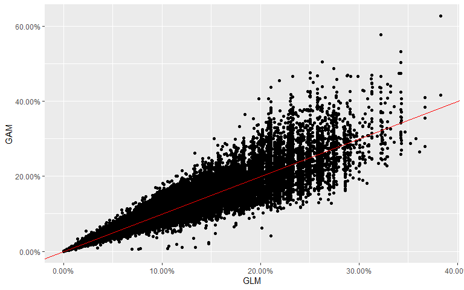

```r
ggplot(testing_set) + geom_point(aes(x=GLM_pred, y=GAM_pred))+ylab("GAM")+xlab("GLM")+geom_abline(slope=1, intercept=0, color="red")+
  scale_x_continuous(labels = scales::percent_format(accuracy = 0.01))+
  scale_y_continuous(labels = scales::percent_format(accuracy = 0.01))
```

This phenomenon might be explained by the use of smoothed continuous variables instead of factorized ones in the GLM. The smoothing function enables us to deal with continuous variables in a more reliable way and thus further refine risk differentiation instead of classifying and generalizing effects over a potentially unrepresentative subgroup. Furthermore, the GAM also enables us to use spatial differentiation which might also be a crucial indicator for risk identification. Altogether, dealing with continuous variables more efficiently with GAM has a positive impact on our model accuracy but also on interpretation as the differentiation between different risk profiles is more refined. Using A GAM, despite its heavier computation time, may helps the insurer provide a more accurate picture of the risk in his portfolio and properly assess it to aim for more accurate pricing when dealing with an actuarial matter.

When computing the total amount of claims resulting from our prediction, we obtain a slightly lower amount for the GAM model than for the GLM.

```r
sum(testing_set$GLM_pred);sum(testing_set$GAM_pred)
```

```
## [1] 4070.769
```

```
## [1] 4060.702
```

### Analysis of the smoothed functions

Let’s now explore in a more detailed way the different smoothed functions we have computed and their interpretation.

First with respect to *POWER*, we observe a straightforward interpretation of the effect of the horsepower of the vehicle on the amount of claims. Indeed, claim frequency rises as the vehicle has more power while we observe more uncertainty with a wider confidence interval the higher the horsepower in kw.

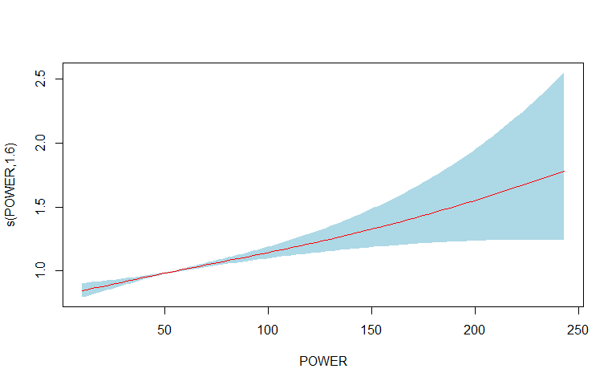

```r
plot(m6_bam , select=1 , trans = exp, scale = 0, shade = TRUE, shade.col = "lightblue", col="red")
```

Now with respect to the car’s age, we tend to observe in our portfolio that the older the car, the lower the frequency of claims we obtain, but with again, a higher variance. The only period where there is a higher frequency is for rather new vehicles (under 5 years), which might be explained by the urge of policyholders to extract the most of their vehicle. Another hypothesis could be for policyholders who change vehicle more regularly due to accidents could fall fall in that category.

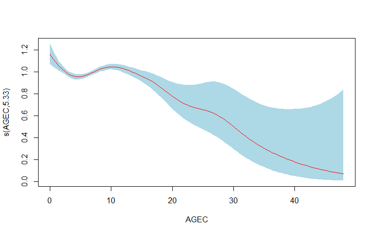

```r
plot(m6_bam , select=2 , trans = exp, scale = 0, shade = TRUE, shade.col = "lightblue", col="red")
```

We have already seen while binning the age of policyholders in the GLM section that amount of claims is highly influenced by the age of policyholders. But since we evaluate the age and its interaction with the sex, we see two different patterns regarding the gender of the insured. On the one hand, Men follow the same pattern observed for the overall portfolio, representing high risk and claim frequency at young ages (18 to 25). We then have a downward trend for middle aged men as the driver gets more driving experience and maturity. Finally, we observe an upward slope for elderly people that are seen to be causing more claims due to various factors impacted by their age. For example, poorer eyesight as the policyholder ages might be a leading cause of higher claims. As a result, the age group around 65 for men is the safest risk profile based on our observations.

Women exhibit a distinctly different claim frequency trajectory across their lifespan compared to men. Young female drivers (age 18) are initially considered higher risk due to limited driving experience, with claim frequencies approximately 20% above the reference level. However, this elevated risk diminishes rapidly, albeit with some fluctuation.

Interestingly, middle-aged women and middle-aged men exhibit comparable claim frequencies, suggesting that gender differences in driving risk are most pronounced at the extremes of the age distribution rather than during the middle years. This pattern may reflect differences in driving behavior, risk exposure, or compensatory strategies that evolve differentially by gender across the lifespan.

A notable transition occurs around age 50, where female drivers reach parity with the reference level. Unlike their male counterparts, women continue to demonstrate declining claim frequencies beyond this point, with no evidence of the upward trend observed in older male drivers. Although, these are the analysis and prediction of our model, but the lack of data for older ages displays a higher variance for elderly, which could also results in an upward trend as indicated by the confidence interval.

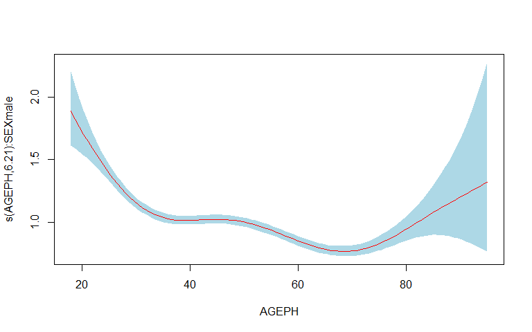

```r
plot(m6_bam , select=3 , trans = exp, scale = 0, shade = TRUE, shade.col = "lightblue", col="red")
```

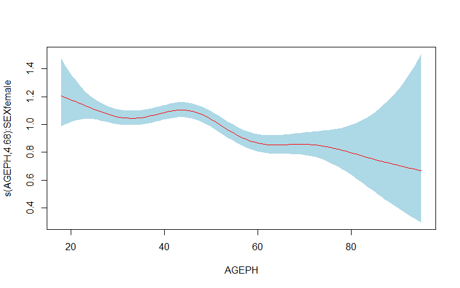

```r
plot(m6_bam , select=4 , trans = exp, scale = 0, shade = TRUE, shade.col = "lightblue", col="red")
```

Finally, we have the position on the bonus-malus scale which is highly correlated with the amount of claims and thus highly impact the frequency predictions. Let’s recall that the higher a policyholder is on the ladder, the more claims that person declared in the recent years. As a result, the claim history of a person has a major influence on the claim frequency as it means that the policyholder has reported claims lately, especially to land in the higher levels. For this reason, we observe an upward effect of the frequency respective to the level on the bonus-malus scale.

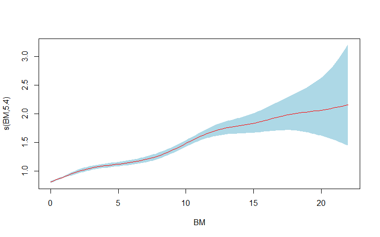

```r
plot(m6_bam , select=5 , trans = exp, scale = 0, shade = TRUE, shade.col = "lightblue", col="red")
```

A general remark regarding the smoothed functions is that we almost always observe higher prediction interval for extreme values (low and/or high). This is explained by the lower amount of observed data in those extreme cases, which makes it more difficult for the model to provide a narrower prediction interval. Lower observations might thus lead to higher variance for a same value, even if continuous.

To conclude this project let’s review the spatial effect with respect to longitude and latitude on the claim frequencies. Here is the plot we obtain based on the bam fitted model.

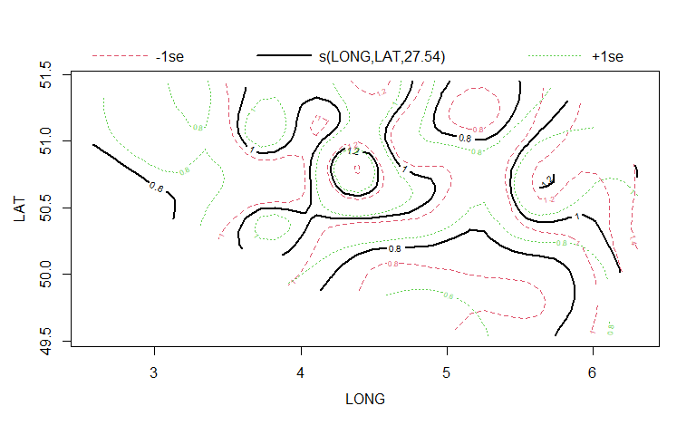

```r
plot(m6_bam , select=6 , trans = exp, scale = 0, shade = TRUE)
```

Based on the previous model we can see clusters where there is a higher predicted frequency of claims. We thus tried a more visual representation of the frequency on a belgian map. Unfortunately, due to issues loading maps with an administrative level above states, We had to stick with a colored map as such. But we still may observe a higher claim frequency trend for most populated areas such as Brussels, Walloon Brabant, Liege and East-Flanders.

```r
library(sf)
library(ggplot2)
library(dplyr)

library(rnaturalearth)
library(rnaturalearthdata)
belgium_sf <- ne_states(country = "belgium", returnclass = "sf")

# Belgium states
belgium_centroids <- st_centroid(belgium_sf)
coords <- st_coordinates(belgium_centroids)

belgium_sf$LONG <- coords[, "X"]
belgium_sf$LAT <- coords[, "Y"]

# median of variables
belgium_sf$AGEC <- median(training_set$AGEC, na.rm = TRUE)
belgium_sf$AGEPH <- median(training_set$AGEPH, na.rm = TRUE)
belgium_sf$EXP <- 1

belgium_pred <- belgium_sf %>%
  mutate(
    # median of continuous variables
    AGEC = median(training_set$AGEC, na.rm = TRUE),
    AGEPH = median(training_set$AGEPH, na.rm = TRUE),
    POWER = median(training_set$POWER, na.rm = TRUE),
    BM = median(training_set$BM, na.rm = TRUE),
    EXP = 1,

    # discret variables
    COVERAGE = names(which.max(table(training_set$COVERAGE))),
    FUEL = names(which.max(table(training_set$FUEL))),
    SEX = names(which.max(table(training_set$SEX))),
    USE = names(which.max(table(training_set$USE))),
    FLEET = names(which.max(table(training_set$FLEET)))
  )

# Spatial effect for each state
belgium_pred$spatial_effect <- predict(m6_bam,
                                     newdata = belgium_pred,
                                     type = "terms")[, "s(LONG,LAT)"]
str(belgium_pred$spatial_effect)
```

```
##  num [1:11] -0.09376 0.00469 -0.19096 -0.32012 0.1076 ...
```

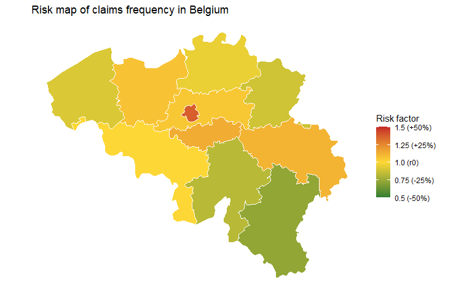

```r
# multiplicator factor
belgium_pred$risk_factor <- exp(as.numeric(belgium_pred$spatial_effect))

library(ggplot2)
library(viridis)

ggplot(belgium_pred) +
  geom_sf(aes(fill = risk_factor), color = "white", size = 0.1) +
  scale_fill_gradient2(
    low = "#2E7D32",      # low risk
    mid = "#FDD835",      # medium risk
    high = "#C62828",     # high risk
    midpoint = 1,
    name = "Risk factor",
    limits = c(0.5, 1.5),
    breaks = seq(0.5, 1.5, 0.25),
    labels = c("0.5 (-50%)", "0.75 (-25%)", "1.0 (r0)",
               "1.25 (+25%)", "1.5 (+50%)")
  ) +
  labs(
    title = "Risk map of claims frequency in Belgium"
  ) +
  theme_minimal() +
  theme(
    axis.text = element_blank(),
    axis.ticks = element_blank(),
    axis.title = element_blank(),
    panel.grid = element_blank(),
    legend.position = "right"
  )
```